# Google Data Analytics Capstone Project

Damani Hylton

2023-01-20

# Bellabeat Analysis

### Business Task

Identify opportunities for growth by analyzing smart device usage in order to gain insight into how consumers use non-Bellabeat smart devices.

### About the Company

Bellabeat is a high-tech company that manufactures health-focused smart products. Since it was founded in 2013, Bellabeat has grown rapidly and quickly positioned itself as a tech-driven wellness company for women. Collecting data on activity, sleep, stress, and reproductive health has allowed Bellabeat to empower women with knowledge about their own health and habits.

### Setting up environment

Notes: setting up my R environment by loading the ‘tidyverse’, ‘ggplot2’ , ‘lubridate’ , ‘dplyr’, ‘janitor’ and ‘readr’ packages:

```r
library(tidyverse)
```

```r
library(ggplot2)
library(lubridate)
library(dplyr)
library(janitor)
library(readr)
```

### Importing CSV files:

Importing dailyActivity_merged csv

```r
daily_fitness_data <- read_csv("~/Data_Analyst_Portfolio/BellaBeat_Project/20160412-20160512_Fitbit_Data/daily_metrics_merged/dailyActivity_merged.csv")
```

Importing sleepDay_merged csv

```r
sleep_Total <- read_csv("~/Data_Analyst_Portfolio/BellaBeat_Project/20160412-20160512_Fitbit_Data/sleepDay_merged.csv")
```

Importing hourlySteps_merged csv

```r
hourSteps <- read_csv("~/Data_Analyst_Portfolio/BellaBeat_Project/20160412-20160512_Fitbit_Data/hourlySteps_merged.csv")
```

Importing hourlyCalories_merged csv

```r
hourlyCalories <- read_csv("~/Data_Analyst_Portfolio/BellaBeat_Project/20160412-20160512_Fitbit_Data/hourlyCalories_merged.csv")
```

## Previewing loaded data

1- Looking at daily_fitness_data.

```r
head(daily_fitness_data)
```

```
## # A tibble: 6 × 15
##       Id Activ…¹ Total…² Total…³ Track…⁴ Logge…⁵ VeryA…⁶ Moder…⁷ Light…⁸ Seden…⁹
##    <dbl> <chr>     <dbl>   <dbl>   <dbl>   <dbl>   <dbl>   <dbl>   <dbl>   <dbl>
## 1 1.50e9 4/12/2…   13162    8.5     8.5        0    1.88   0.550    6.06       0
## 2 1.50e9 4/13/2…   10735    6.97    6.97       0    1.57   0.690    4.71       0
## 3 1.50e9 4/14/2…   10460    6.74    6.74       0    2.44   0.400    3.91       0
## 4 1.50e9 4/15/2…    9762    6.28    6.28       0    2.14   1.26     2.83       0
## 5 1.50e9 4/16/2…   12669    8.16    8.16       0    2.71   0.410    5.04       0
## 6 1.50e9 4/17/2…    9705    6.48    6.48       0    3.19   0.780    2.51       0
## # … with 5 more variables: VeryActiveMinutes <dbl>, FairlyActiveMinutes <dbl>,
## #   LightlyActiveMinutes <dbl>, SedentaryMinutes <dbl>, Calories <dbl>, and
## #   abbreviated variable names ¹ActivityDate, ²TotalSteps, ³TotalDistance,
## #   ⁴TrackerDistance, ⁵LoggedActivitiesDistance, ⁶VeryActiveDistance,
## #   ⁷ModeratelyActiveDistance, ⁸LightActiveDistance, ⁹SedentaryActiveDistance
```

2- Identifying column names for daily_fitness_data

```r
colnames(daily_fitness_data)
```

```
##  [1] "Id"                       "ActivityDate"
##  [3] "TotalSteps"               "TotalDistance"
##  [5] "TrackerDistance"          "LoggedActivitiesDistance"
##  [7] "VeryActiveDistance"       "ModeratelyActiveDistance"
##  [9] "LightActiveDistance"      "SedentaryActiveDistance"
## [11] "VeryActiveMinutes"        "FairlyActiveMinutes"
## [13] "LightlyActiveMinutes"     "SedentaryMinutes"
## [15] "Calories"
```

3- Looking at sleep_Total data

```r
head(sleep_Total)
```

```
## # A tibble: 6 × 5
##           Id SleepDay              TotalSleepRecords TotalMinutesAsleep TotalT…¹
##        <dbl> <chr>                             <dbl>              <dbl>    <dbl>
## 1 1503960366 4/12/2016 12:00:00 AM                 1                327      346
## 2 1503960366 4/13/2016 12:00:00 AM                 2                384      407
## 3 1503960366 4/15/2016 12:00:00 AM                 1                412      442
## 4 1503960366 4/16/2016 12:00:00 AM                 2                340      367
## 5 1503960366 4/17/2016 12:00:00 AM                 1                700      712
## 6 1503960366 4/19/2016 12:00:00 AM                 1                304      320
## # … with abbreviated variable name ¹TotalTimeInBed
```

4- Looking at hourlySteps_merged data

```r
head(hourSteps)
```

```
## # A tibble: 6 × 3
##           Id ActivityHour          StepTotal
##        <dbl> <chr>                     <dbl>
## 1 1503960366 4/12/2016 12:00:00 AM       373
## 2 1503960366 4/12/2016 1:00:00 AM        160
## 3 1503960366 4/12/2016 2:00:00 AM        151
## 4 1503960366 4/12/2016 3:00:00 AM          0
## 5 1503960366 4/12/2016 4:00:00 AM          0
## 6 1503960366 4/12/2016 5:00:00 AM          0
```

5- Looking at hourlyCalories_merged data

```r
head(hourlyCalories)
```

```
## # A tibble: 6 × 3
##           Id ActivityHour          Calories
##        <dbl> <chr>                    <dbl>
## 1 1503960366 4/12/2016 12:00:00 AM       81
## 2 1503960366 4/12/2016 1:00:00 AM        61
## 3 1503960366 4/12/2016 2:00:00 AM        59
## 4 1503960366 4/12/2016 3:00:00 AM        47
## 5 1503960366 4/12/2016 4:00:00 AM        48
## 6 1503960366 4/12/2016 5:00:00 AM        48
```

## Cleaning the imported data

1- Notes: Cleaned the column names for better readability, renamed the ‘Activity Date’ column to ‘date’, assigned YYYY-MM-DD format and changed column datatype from character to ‘Date’

```r
cleaned_daily_fitness <- clean_names(daily_fitness_data)
```

2- Renamed the ‘activity_date’ column to ‘date’.

```r
cleaned_daily_fitness <- cleaned_daily_fitness %>%
  rename(date = activity_date)
```

3- Changed date format to YYYY-MM-DD

```r
cleaned_daily_fitness$date <- mdy(cleaned_daily_fitness$date)
```

4- Added Weekday column to specify Days of the week

```r
cleaned_daily_fitness <- cleaned_daily_fitness %>%
  mutate(week_day = weekdays(as.Date.factor(date)))
```

See the changes made to cleaned_daily_fitness

```r
str(cleaned_daily_fitness)
```

```
## tibble [940 × 16] (S3: tbl_df/tbl/data.frame)
##  $ id                        : num [1:940] 1.5e+09 1.5e+09 1.5e+09 1.5e+09 1.5e+09 ...
##  $ date                      : Date[1:940], format: "2016-04-12" "2016-04-13" ...
##  $ total_steps               : num [1:940] 13162 10735 10460 9762 12669 ...
##  $ total_distance            : num [1:940] 8.5 6.97 6.74 6.28 8.16 ...
##  $ tracker_distance          : num [1:940] 8.5 6.97 6.74 6.28 8.16 ...
##  $ logged_activities_distance: num [1:940] 0 0 0 0 0 0 0 0 0 0 ...
##  $ very_active_distance      : num [1:940] 1.88 1.57 2.44 2.14 2.71 ...
##  $ moderately_active_distance: num [1:940] 0.55 0.69 0.4 1.26 0.41 ...
##  $ light_active_distance     : num [1:940] 6.06 4.71 3.91 2.83 5.04 ...
##  $ sedentary_active_distance : num [1:940] 0 0 0 0 0 0 0 0 0 0 ...
##  $ very_active_minutes       : num [1:940] 25 21 30 29 36 38 42 50 28 19 ...
##  $ fairly_active_minutes     : num [1:940] 13 19 11 34 10 20 16 31 12 8 ...
##  $ lightly_active_minutes    : num [1:940] 328 217 181 209 221 164 233 264 205 211 ...
##  $ sedentary_minutes         : num [1:940] 728 776 1218 726 773 ...
##  $ calories                  : num [1:940] 1985 1797 1776 1745 1863 ...
##  $ week_day                  : chr [1:940] "Tuesday" "Wednesday" "Thursday" "Friday" ...
```

5- Cleaned hourlySteps_merged data Notes: Cleaning up the name format of the columns and changing the date format to YYYY-MM-DD-HH-MM

```r
cleaned_hourlySteps <- clean_names(hourSteps)

cleaned_hourlySteps$activity_hour <- mdy_hms(cleaned_hourlySteps$activity_hour)
```

6- Cleaned sleep_Total data and renamed ‘sleep_day’ to ‘date’

```r
cleaned_sleep_Total <- clean_names(sleep_Total) %>%
  rename(date = sleep_day)

cleaned_sleep_Total$date <- mdy_hms(cleaned_sleep_Total$date)
```

7- Cleaned hourlyCalories data and changed the date format to YYYY-MM-DD-HH-MM

```r
cleaned_hourly_Calories <- clean_names(hourlyCalories)

cleaned_hourly_Calories$activity_hour <- mdy_hms(cleaned_hourly_Calories$activity_hour)
```

Since all the data frames have ‘id’ in common, let’s check how many unique participants and rows are in each dataframe:

```r
n_distinct(cleaned_daily_fitness$id)
```

```
## [1] 33
```

```r
n_distinct(cleaned_sleep_Total$id)
```

```
## [1] 24
```

```r
nrow(cleaned_sleep_Total)
```

```
## [1] 413
```

```r
nrow(unique(cleaned_sleep_Total))
```

```
## [1] 410
```

8- Removed duplicate rows found in ‘cleaned_sleep_total’

```r
cleaned_sleep_Total <- unique(cleaned_sleep_Total)

nrow(cleaned_sleep_Total)
```

```
## [1] 410
```

9- Note: Not all participants logged sleep data, as such, merge data frames by ‘id’ and leave out the participants that did not record sleep data for this merge.

```r
combined_merge <- merge(cleaned_daily_fitness, cleaned_sleep_Total)

n_distinct(combined_merge$id)
```

```
## [1] 24
```

10- Merging the hourly steps and calories data frames by ‘id’ and ‘activity hour’.

```r
combined_hourly <- cleaned_hourlySteps %>%
  inner_join(cleaned_hourly_Calories, by = c("id", "activity_hour"))
```

11- Merging average sleep and average steps taken by participants and creating a new data frame ‘sleep_vs_steps’.

```r
avg_sleeping_mins <- combined_merge %>%
  group_by(id) %>%
  summarize(avg_sleeping_mins = mean(total_minutes_asleep))

avg_total_steps <- combined_merge %>%
  group_by(id) %>%
  summarize(avg_total_steps = mean(total_steps))

sleep_vs_steps <- merge(avg_sleeping_mins, avg_total_steps)
```

Looking at a summary of the combined_merge data

```r
combined_merge %>%
  select(total_steps,
         calories,
         total_minutes_asleep,
         total_time_in_bed) %>%
  summary()
```

```
##   total_steps       calories    total_minutes_asleep total_time_in_bed
##  Min.   :   17   Min.   : 257   Min.   : 58.0        Min.   : 61.0
##  1st Qu.: 5189   1st Qu.:1841   1st Qu.:361.0        1st Qu.:403.8
##  Median : 8913   Median :2207   Median :432.5        Median :463.0
##  Mean   : 8515   Mean   :2389   Mean   :419.2        Mean   :458.5
##  3rd Qu.:11370   3rd Qu.:2920   3rd Qu.:490.0        3rd Qu.:526.0
##  Max.   :22770   Max.   :4900   Max.   :796.0        Max.   :961.0
```

Summary of combined_hourly data

```r
combined_hourly %>%
  select(activity_hour,
         step_total,
         calories) %>%
  summary()
```

```
##  activity_hour                      step_total         calories
##  Min.   :2016-04-12 00:00:00.00   Min.   :    0.0   Min.   : 42.00
##  1st Qu.:2016-04-19 01:00:00.00   1st Qu.:    0.0   1st Qu.: 63.00
##  Median :2016-04-26 06:00:00.00   Median :   40.0   Median : 83.00
##  Mean   :2016-04-26 11:46:42.58   Mean   :  320.2   Mean   : 97.39
##  3rd Qu.:2016-05-03 19:00:00.00   3rd Qu.:  357.0   3rd Qu.:108.00
##  Max.   :2016-05-12 15:00:00.00   Max.   :10554.0   Max.   :948.00
```

Summary of sleep_vs_steps data

```r
sleep_vs_steps %>%
  select(avg_sleeping_mins,
         avg_total_steps) %>%
  summary()
```

```
##  avg_sleeping_mins avg_total_steps
##  Min.   : 61.0     Min.   : 1490
##  1st Qu.:336.3     1st Qu.: 5106
##  Median :417.2     Median : 8336
##  Mean   :377.4     Mean   : 7880
##  3rd Qu.:449.3     3rd Qu.: 9394
##  Max.   :652.0     Max.   :19079
```

### According to the U.S. Department of Health and Human Services, most adults need 7 or more hours of good-quality sleep each night. As such, I am filtering participants that get less than 7 hours sleeping and less than the group average in steps taken daily.

```r
sleep_vs_steps %>%
  filter(avg_sleeping_mins <= 420,
         avg_total_steps <= 7890)
```

```
##           id avg_sleeping_mins avg_total_steps
## 1 1927972279          417.0000        1490.000
## 2 2320127002           61.0000        5079.000
## 3 4020332650          349.3750        6596.750
## 4 4445114986          385.1786        4756.179
## 5 6775888955          349.6667        3499.000
## 6 7007744171           68.5000        5115.500
```

## Analysis

### Now that we have some data cleaned and merged, we can begin some exploratory analysis

#### Figure 1

Checking out if more sleep on average, leads to more average total steps per day

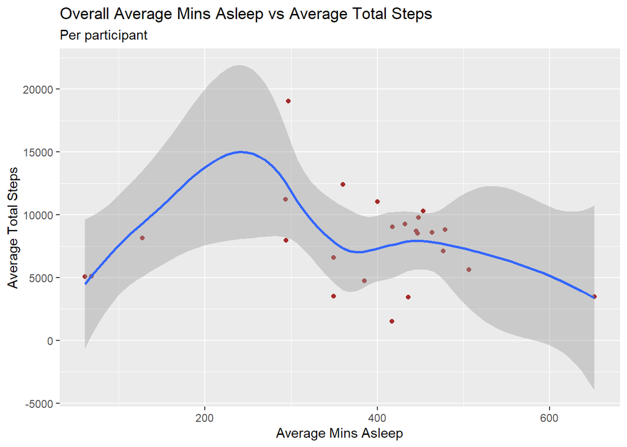

```r
ggplot(data = sleep_vs_steps, mapping = aes(x = avg_sleeping_mins, y = avg_total_steps)) +
  geom_jitter(color = "brown") +
  geom_smooth() +
  labs(title = "Overall Average Mins Asleep vs Average Total Steps", subtitle = "Per participant", x = "Average Mins Asleep", y = "Average Total Steps")
```

```r
cor(sleep_vs_steps$avg_sleeping_mins, sleep_vs_steps$avg_total_steps)
```

```
## [1] -0.06633235
```

#### Figure 2

What days of the week are participants most likely to burn the most calories?

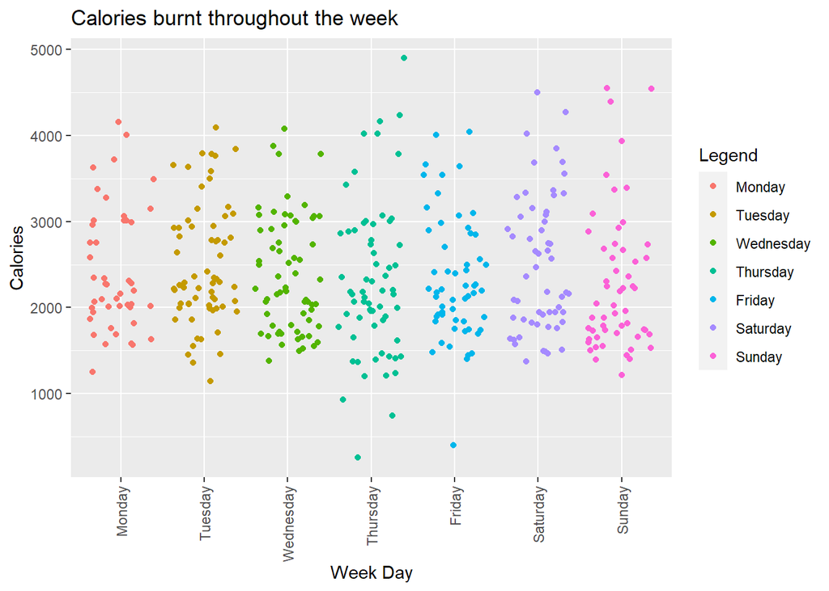

```r
week_dayz <- factor(combined_merge$week_day, levels = c("Monday", "Tuesday", "Wednesday", "Thursday", "Friday", "Saturday", "Sunday"))

ggplot(data = combined_merge, mapping = aes(x = week_dayz, y = calories, color = week_dayz)) +
  geom_point(position = "jitter", stat = "identity") +
  labs(title = "Calories burnt throughout the week") +
  ylab("Calories") +
  scale_x_discrete("Week Day", guide = guide_axis(angle = 90)) +
  scale_color_discrete("Legend")
```

#### Figure 3

Does more time asleep lead to a more active day? Comparing the total minutes asleep and total steps taken to see how they vary during the week.

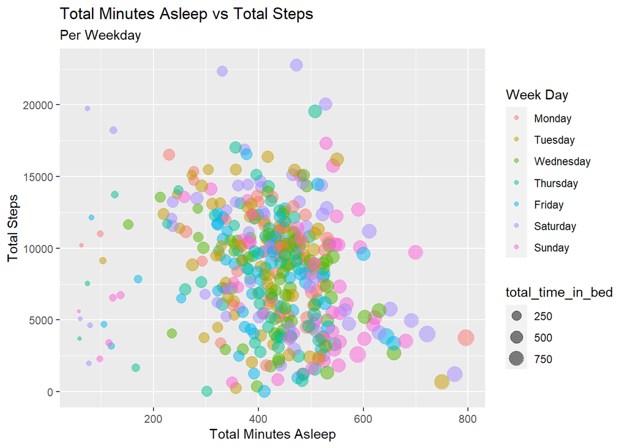

```r
ggplot(data = combined_merge, mapping = aes(x = total_minutes_asleep, y = total_steps, color = week_dayz, size = total_time_in_bed)) +
  geom_point(alpha = 0.5) +
  labs(title = "Total Minutes Asleep vs Total Steps", subtitle = "Per Weekday", x = "Total Minutes Asleep", y = "Total Steps") +
  theme(legend.position = "right") +
  scale_color_discrete("Week Day")
```

#### Figure 4 Hourly Activity: what hours are the participants most active?

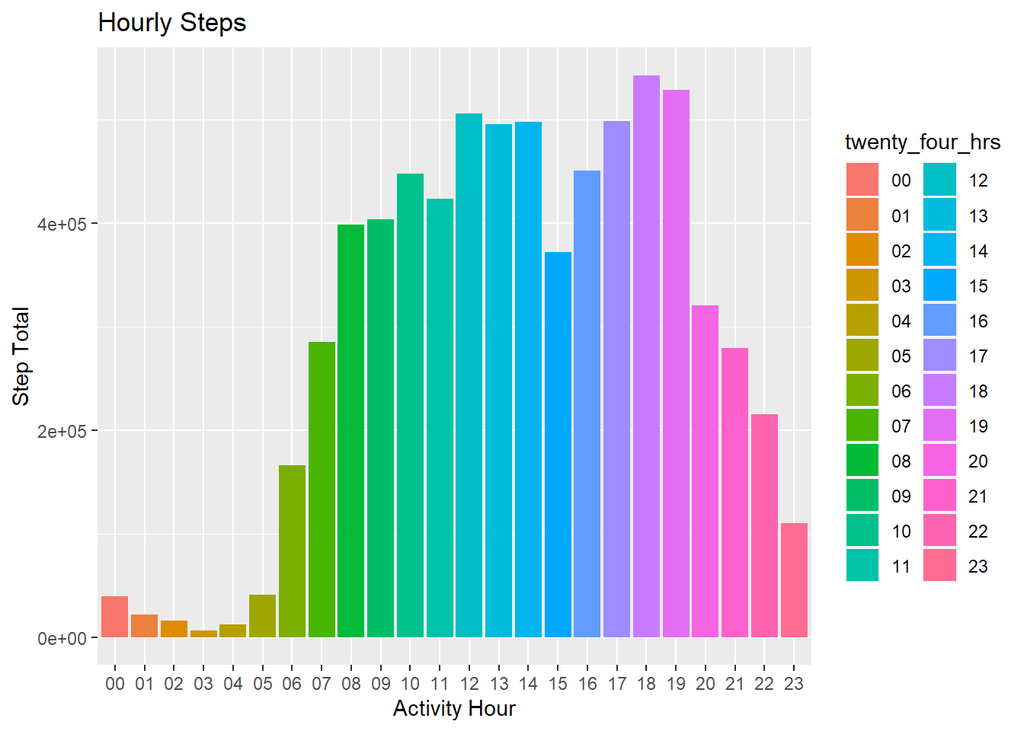

```r
twenty_four_hrs <- format(as.POSIXct(combined_hourly$activity_hour), format = "%H")

ggplot(data = combined_hourly, aes(x = twenty_four_hrs, y = step_total, fill = twenty_four_hrs)) +
  geom_bar(stat = "identity") +
  labs(title = "Hourly Steps", x = "Activity Hour", y = "Step Total")
```

```r
combined_merge %>%
  group_by(id) %>%
  summarize(sumz = sum(total_steps))
```

```
## # A tibble: 24 × 2
##            id   sumz
##         <dbl>  <dbl>
##  1 1503960366 310142
##  2 1644430081  31871
##  3 1844505072  10431
##  4 1927972279   7450
##  5 2026352035 157323
##  6 2320127002   5079
##  7 2347167796 127998
##  8 3977333714 314104
##  9 4020332650  52774
## 10 4319703577 185261
## # … with 14 more rows
```

### Recommendations

1. The Bellabeat Membership (app) should notify it’s users when they ‘fall’ out of the average inactivity period during certain times of the day. One way to monitor activity is by steps taken per hour and if the app calculates that the user would not make their recommended steps per day, give them notifications and reminders.
2. Bellabeat should incorporate the Bellabeat membership into everyday living and activity monitoring. If for some reason a user has been in bed but spending less time sleeping for a couple days, someone from Bellabeat could do a quick check in on the user, either via text or video.
3. Wellness sessions can also take place right from the Bellabeat membership app* that allows users to unwind on a stressful day, while also incorporating light exercises, for example yoga. To capitalize on this, looking into exercise equipment, like an stationary bike, could be a new revenue stream.
4. Users of the Bellabeat membership app* should have access to chefs’ personalized menu, that can cater meals that heal, nurture and rejuvenate users for another day.